# Business Statistics End of Term Assessment IB94X0 2024-2025 #1

5642990

```r
library(tidyverse)
library(emmeans) # for emmeans() and pairs()
library(Hmisc)
options(width=100)
library(kableExtra)
library(gridExtra)
library(car)
```

This is to certify that the work I am submitting is my own. All external references and sources are clearly acknowledged and identified within the contents. I am aware of the University of Warwick regulation concerning plagiarism and collusion.

No substantial part(s) of the work submitted here has also been submitted by me in other assessments for accredited courses of study, and I acknowledge that if this has been done an appropriate reduction in the mark I might otherwise have received will be made.

AI was used in the preparation of this work. It was used in the development of the code: It was used to provide example uses of functions or approaches to elements of the challenges which were then interpreted by me and modified to be applicable to this data/report.

# Question 1

## Introduction

Section 1 will evaluate how the population percentage of poverty, overweight, smokers, and wellbeing score in an area will effect the prevalence of cardiovascular disease (CVD). The effect of percentage of poverty in population upon CVD will also be illustrated. Firstly the data is loaded and explored, then it is modelled. Findings suggest that higher percentages of overweight individuals, smokers, and wellbeing scores are associated with an increased occurrence of CVD. However, higher poverty rates appear to be linked to a lower prevalence of CVD, with the relationship between overweight and poverty showing a statistically significant interaction.

```r
cvd <- read_csv("Cardio_Vascular_Disease.csv") #loading the data
```

## Data dictionary

| Variable | Description |
| --- | --- |
| area_name | The name of the area |
| area_code | The code of the area |
| Population | The number of population living in the area |
| Poverty | The proportion of population living in poverty |
| CVD | The percentage of people living in the area who have recently experienced Cardiovascular Disease (CVD) |
| overweight | The proportion of population who are overweight |
| smokers | The proportion of population who smoke |
| wellbeing | The average wellbeing score on the area |

## Data Exploration and Preparation

Data is explored and prepared by checking duplicate values, Null values, and possible outliers that might bias the result.

### Duplicate value evaluation

```r
(area_duplicate <-cvd%>%
  filter(duplicated(cvd$area_name)))
```

```
## # A tibble: 0 × 8
## # ℹ 8 variables: area_name <chr>, area_code <chr>, Population <dbl>, Poverty <dbl>, CVD <dbl>,
## #   overweight <dbl>, smokers <dbl>, wellbeing <dbl>
```

```r
(code_duplicate <-cvd%>%
  filter(duplicated(cvd$area_code)))
```

```
## # A tibble: 0 × 8
## # ℹ 8 variables: area_name <chr>, area_code <chr>, Population <dbl>, Poverty <dbl>, CVD <dbl>,
## #   overweight <dbl>, smokers <dbl>, wellbeing <dbl>
```

Checking duplicate values on the area name and area code shows that there is no duplicated values on both area names and area code.

### Null value evaluation

```r
colSums(is.na(cvd))
```

```
##  area_name  area_code Population    Poverty        CVD overweight    smokers  wellbeing
##          0          0         76         76         76         72          7         15
```

```r
NAs <- cvd %>%
  filter(rowSums(is.na(cvd))>0)
```

There are Null values in the dataset, ideally this should be consulted with the provider of the data. In this case, I will use linear modelling which by default will remove entire rows of the dataset that contains Null value.

### Distribution of data evaluation

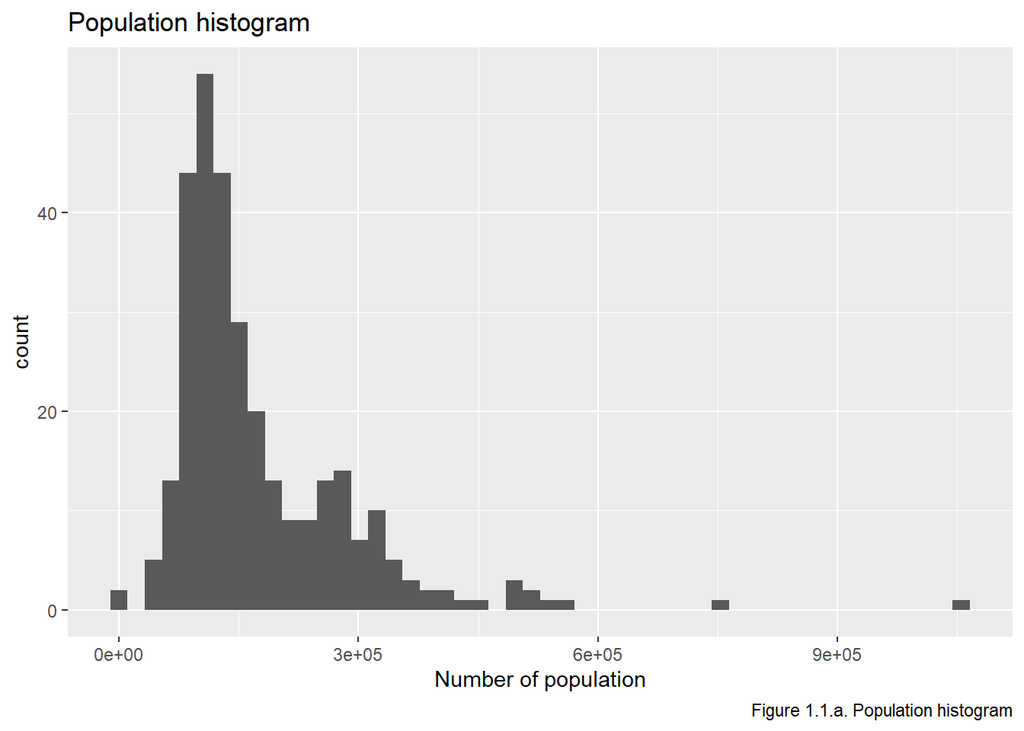

```r
ggplot(data = cvd, aes(x=Population))+
  geom_histogram(bins=50)+
  labs(x= "Number of population", title="Population histogram", caption = "Figure 1.1.a. Population histogram")
```

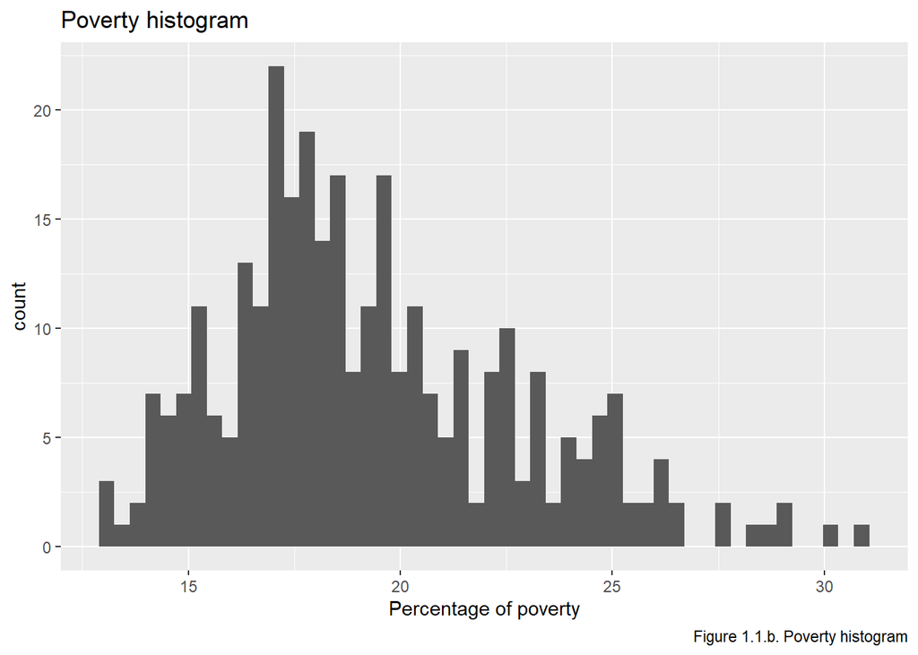

```r
ggplot(data = cvd, aes(x=Poverty))+
  geom_histogram(bins=50)+
  labs(x= "Percentage of poverty", title="Poverty histogram", caption = "Figure 1.1.b. Poverty histogram")
```

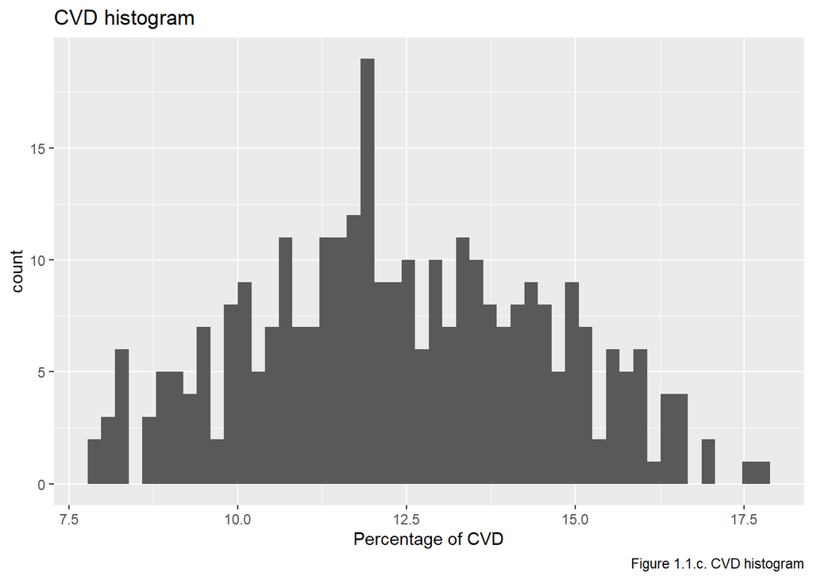

```r
ggplot(data = cvd, aes(x=CVD))+
  geom_histogram(bins=50)+
  labs(x= "Percentage of CVD", title="CVD histogram", caption = "Figure 1.1.c. CVD histogram")
```

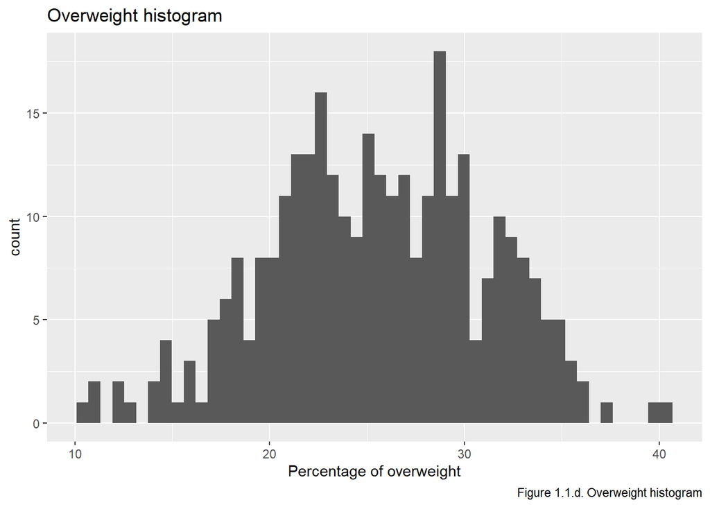

```r
ggplot(data = cvd, aes(x=overweight))+
  geom_histogram(bins=50)+
  labs(x= "Percentage of overweight", title="Overweight histogram", caption = "Figure 1.1.d. Overweight histogram")
```